# Mariners 2022

Nicholas Kondo

# 1. Exploratory Data Analysis

This is a very imbalanced data set. Home Runs occur less than 1% of all pitches. Let’s take a look below on Home Runs across pitch types.

```r
train %>%
    filter(!is.na(pitch_type)) %>%
    mutate(pitch_type = fct_lump(pitch_type, prop = 0.05)) %>%
    count(pitch_type, is_hr) %>%
    group_by(pitch_type) %>%
    mutate(percent = scales::percent(n/sum(n))) %>%
    kable(col.names = c("Pitch Type", "Is_HR?", "Number of HRs", "% of HRs"),
        align = "llrr")
```

| Pitch Type | Is_HR? | Number of HRs | % of HRs |
| --- | --- | --- | --- |
| CH | 0 | 32170 | 99% |
| CH | 1 | 280 | 1% |
| CU | 0 | 21741 | 99% |
| CU | 1 | 158 | 1% |
| FA | 0 | 119190 | 99% |
| FA | 1 | 1206 | 1% |
| KN | 0 | 1416 | 100% |
| KN | 1 | 7 | 0% |
| SI | 0 | 33804 | 99% |
| SI | 1 | 248 | 1% |
| SL | 0 | 56656 | 99% |
| SL | 1 | 459 | 1% |

## 1.1 Pitch Location

Let’s look at how the location of pitches affects the probability of hitting a home run. This heat map aligns with our baseball inference that pitches closer to the middle of the zone are more likely to be hit for a home run. It’d be interesting to look at heat maps for different types of pitches and separately for RHP and LHP and splits based on pitch type.

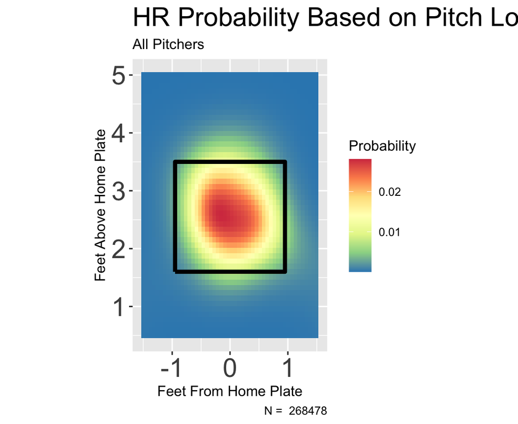

```r
# Creating generalized model
fit <- gam(is_hr ~ s(plate_side, plate_height), family = binomial, data = train)
# Finding predicted probabilities over a 50 x 50 grid
x <- seq(-1.5, 1.5, length.out = 50)
y <- seq(0.5, 5, length.out = 50)
data.predict <- data.frame(plate_side = c(outer(x, y * 0 + 1)), plate_height = c(outer(x *
    0 + 1, y)))
# Creating LP model
lp <- predict(fit, data.predict)
# Adding the probability of hitting a home run given the location
data.predict$Probability <- exp(lp)/(1 + exp(lp))
# Creating the K Zone
topKzone <- 3.5
botKzone <- 1.6
inKzone <- -0.95
outKzone <- 0.95
kZone <- data.frame(x = c(inKzone, inKzone, outKzone, outKzone, inKzone),
    y = c(botKzone, topKzone, topKzone, botKzone, botKzone))
# Constructing the plot for ALL pitchers
ggplot(kZone, aes(x, y)) + geom_tile(data = data.predict, aes(x = plate_side,
    y = plate_height, fill = Probability)) + scale_fill_distiller(palette = "Spectral") +
    geom_path(lwd = 1.5, col = "black") + coord_fixed() + labs(title = "HR Probability Based on Pitch Location",
    subtitle = "All Pitchers", y = "Feet Above Home Plate", x = "Feet From Home Plate",
    caption = paste("N = ", nrow(train))) + theme(axis.text = element_text(size = 20),
    plot.title = element_text(size = 20))
```

## 1.2 Missing Values

Exploring the missing values across the data set.

```r
sort(colSums(is.na(train)))
```

```
##                date          pitcher_id        pitcher_side
##                   0                   0                   0
##           batter_id         batter_side          stadium_id
##                   0                   0                   0
##           umpire_id          catcher_id              inning
##                   0                   0                   0
##          top_bottom                outs               balls
##                   0                   0                   0
##             strikes          rel_height            rel_side
##                   0                   0                   0
##        plate_height          plate_side          zone_speed
##                   0                   0                   0
##                 x55                 y55                 z55
##                   0                   0                   0
##            pitch_id               is_hr       release_speed
##                   0                   0                   3
##  vert_release_angle  horz_release_angle vert_approach_angle
##                   3                   3                   3
## horz_approach_angle           extension           spin_axis
##                   3                  12                 168
##                tilt          vert_break  induced_vert_break
##                 168                 171                 171
##          horz_break          pitch_type           spin_rate
##                 171                1143                1393
```

There are a lot of NA values for pitch type… let’s check out the different types of pitches.

```r
train$pitch_type <- as.factor(train$pitch_type)
table(train$pitch_type)
```

```
##
##     CH     CU     FA     KN     SI     SL
##  32450  21899 120396   1423  34052  57115
```

```r
NA_pitchType <- train %>%
    filter(is.na(train$pitch_type))
```

# 2. Feature Engineering

The first section of feature engineering will deal with our missing values. Next, we will normalize horizontal metrics for righties and lefties, followed by a count variable, and a variable that represents the type of matchup.

## 2.1 Handling Missing Values

Most models don’t allow any missing values. In this section we are going to take steps to address these missing values, particularly focusing on pitch type and spin rate where we see the most missing data.

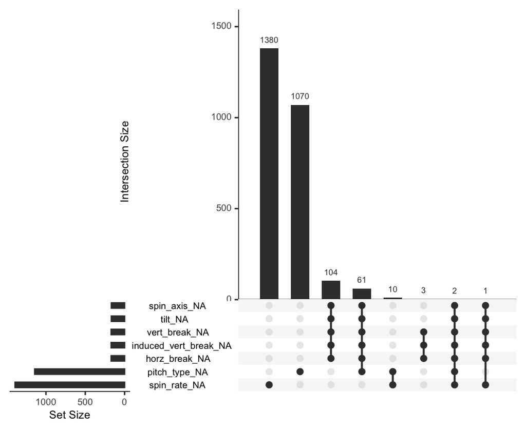

```r
gg_miss_upset(train, nsets = 7)
```

The NA values for pitch type seem to be somewhat normal- meaning the pitches weren’t spiked in the ground or thrown over the backstop, and some actually were even hit for home run. We should try to keep this data. My assumption is that not every pitch can fall under a pitch classification. For example, we have 6 classes of pitch type: `FA` `CU` `CH` `SL` `SI` and `KN`. What would we classify a knuckle-curve? The best way to preseve this data is by implementing an “other” class for all the missing values.

```r
# Creating a new data set and removing ID variables
train1 <- train %>%
    select(-date, -umpire_id, -catcher_id, -inning, -top_bottom, -y55,
        -pitch_id, -pitcher_id, -batter_id, -tilt, -stadium_id, -inning,
        -outs)
# Changing to character
train1$pitch_type <- as.character(train1$pitch_type)
# Changing NA values to other
train1$pitch_type[is.na(train1$pitch_type)] <- "other"
train1$pitch_type <- as.factor(train1$pitch_type)

# Confirming NA values
sort(colSums(is.na(train1)))
```

```
##        pitcher_side         batter_side               balls
##                   0                   0                   0
##             strikes          rel_height            rel_side
##                   0                   0                   0
##        plate_height          plate_side          zone_speed
##                   0                   0                   0
##                 x55                 z55          pitch_type
##                   0                   0                   0
##               is_hr       release_speed  vert_release_angle
##                   0                   3                   3
##  horz_release_angle vert_approach_angle horz_approach_angle
##                   3                   3                   3
##           extension           spin_axis          vert_break
##                  12                 168                 171
##  induced_vert_break          horz_break           spin_rate
##                 171                 171                1393
```

```r
levels(train1$pitch_type)
```

```
## [1] "CH"    "CU"    "FA"    "KN"    "other" "SI"    "SL"
```

### a. Spin Rate

To accommodate for spin rate missing values, we are going to impute the median spin rate based on the type of pitch. To do this first we need to separate the pitches by pitch type, compute the median, then impute the median for the missing values.

```r
# Creating separate data sets for each pitch type
fastballs <- train1 %>%
    filter(pitch_type == "FA")
curveballs <- train1 %>%
    filter(pitch_type == "CU")
changeups <- train1 %>%
    filter(pitch_type == "CH")
sinkers <- train1 %>%
    filter(pitch_type == "SI")
sliders <- train1 %>%
    filter(pitch_type == "SL")
knuckleballs <- train1 %>%
    filter(pitch_type == "KN")
others <- train1 %>%
    filter(pitch_type == "Other")

# Filling all NA spin_rate values with the median spin rate of that
# respective pitch
fastballs$spin_rate[is.na(fastballs$spin_rate)] <- median(fastballs$spin_rate,
    na.rm = TRUE)
curveballs$spin_rate[is.na(curveballs$spin_rate)] <- median(curveballs$spin_rate,
    na.rm = TRUE)
changeups$spin_rate[is.na(changeups$spin_rate)] <- median(changeups$spin_rate,
    na.rm = TRUE)
sinkers$spin_rate[is.na(sinkers$spin_rate)] <- median(sinkers$spin_rate,
    na.rm = TRUE)
sliders$spin_rate[is.na(sliders$spin_rate)] <- median(sliders$spin_rate,
    na.rm = TRUE)
knuckleballs$spin_rate[is.na(knuckleballs$spin_rate)] <- median(knuckleballs$spin_rate,
    na.rm = TRUE)
others$spin_rate[is.na(others$spin_rate)] <- median(others$spin_rate, na.rm = TRUE)

# Combining our separate data sets back together
train1 <- bind_rows(fastballs, curveballs, changeups, sinkers, sliders,
    knuckleballs, others)
# Freeing memory
rm(fastballs, curveballs, changeups, sinkers, sliders, knuckleballs, others)

# Checking our NA values again
sort(colSums(is.na(train1)))
```

```
##        pitcher_side         batter_side               balls
##                   0                   0                   0
##             strikes           spin_rate          rel_height
##                   0                   0                   0
##            rel_side        plate_height          plate_side
##                   0                   0                   0
##          zone_speed                 x55                 z55
##                   0                   0                   0
##          pitch_type               is_hr       release_speed
##                   0                   0                   3
##  vert_release_angle  horz_release_angle vert_approach_angle
##                   3                   3                   3
## horz_approach_angle           extension           spin_axis
##                   3                  11                 105
##          vert_break  induced_vert_break          horz_break
##                 108                 108                 108
```

### b. Other Missing/Usual Values

At this stage, we don’t have many more missing values. There are a series of unusual values where `vert_break`, `induced_break`, and `horz_break` have values of 0.0000. We will remove the remaining unusual and missing values.

```r
# Table of our NA values for break, notice horz_break are missing as
# well
train1 %>%
    filter(is.na(vert_break))
```

| pitcher_side | batter_side | balls | strikes | release_speed | vert_release_angle | horz_release_angle | spin_rate | spin_axis | rel_height | rel_side | extension | vert_break | induced_vert_break | horz_break | plate_height | plate_side | zone_speed | vert_approach_angle | horz_approach_angle | x55 | z55 | pitch_type | is_hr |
| --- | --- | --- | --- | --- | --- | --- | --- | --- | --- | --- | --- | --- | --- | --- | --- | --- | --- | --- | --- | --- | --- | --- | --- |
| Right | Left | 0 | 0 | 96.5599 | -2.720830 | -2.376530 | 1961.95 | NA | 6.12665 | 1.53241 | 6.35745 | NA | NA | NA | 2.20627 | 0.07253 | 88.5195 | -5.68402 | -0.621151 | -1.535720 | 6.15758 | FA | 0 |
| Right | Right | 0 | 0 | 95.3861 | -3.849840 | -4.237090 | 2500.54 | NA | 5.50939 | 2.18466 | 5.49121 | NA | NA | NA | 1.34848 | -0.37099 | 85.1898 | -5.09048 | -1.228950 | -2.138320 | 5.48859 | FA | 0 |
| Right | Right | 3 | 2 | 96.4309 | -2.599390 | -4.092180 | 2262.27 | NA | 6.73122 | 2.89153 | 6.56170 | NA | NA | NA | 4.46536 | 0.44546 | 86.1939 | -2.45868 | -1.191670 | -2.938090 | 6.75686 | FA | 0 |
| Right | Right | 0 | 1 | 94.0546 | -4.600090 | -3.604980 | 2402.54 | NA | 6.10580 | 1.50760 | 5.76323 | NA | NA | NA | 2.08431 | -0.85613 | 84.4963 | -4.07856 | -1.454520 | -1.487390 | 6.09869 | FA | 0 |
| Right | Left | 0 | 0 | 93.4478 | -4.567410 | -2.427740 | 2041.45 | NA | 6.39582 | 1.86378 | 6.82001 | NA | NA | NA | 0.85322 | 0.43612 | 84.5143 | -6.85934 | -0.574775 | -1.878800 | 6.45729 | FA | 0 |
| Right | Left | 1 | 2 | 91.9459 | -2.206890 | -3.097740 | 2174.10 | NA | 5.84737 | 2.04166 | 5.85183 | NA | NA | NA | 1.95397 | 0.25266 | 83.7254 | -6.18999 | -0.735625 | -2.025550 | 5.85376 | FA | 0 |
| Left | Left | 0 | 0 | 92.3856 | -2.314210 | 3.305120 | 2364.41 | NA | 6.78877 | -2.26937 | 6.68042 | NA | NA | NA | 3.78771 | 0.43131 | 82.5327 | -4.19773 | 2.574150 | 2.321450 | 6.82349 | FA | 0 |
| Left | Right | 1 | 0 | 89.5311 | -3.943930 | 2.384030 | 2187.15 | NA | 6.46757 | -3.06331 | 5.38358 | NA | NA | NA | 2.32549 | -1.04875 | 80.0176 | -4.95541 | 1.946170 | 3.050210 | 6.43944 | FA | 0 |
| Right | Left | 1 | 2 | 97.2628 | -3.207620 | -2.250840 | 2600.20 | NA | 6.12784 | 1.53881 | 5.56082 | NA | NA | NA | 3.36843 | 0.32875 | 85.8087 | -2.66053 | -0.311900 | -1.517860 | 6.08268 | FA | 0 |
| Right | Left | 3 | 2 | 94.9105 | -3.096480 | -4.500310 | 2376.58 | NA | 5.85057 | 1.56448 | 5.96373 | NA | NA | NA | 1.86915 | -1.11802 | 86.8110 | -5.42624 | -1.291760 | -1.558300 | 5.86286 | FA | 0 |

[output cut: 98 more lines]

```r
# Table that shows our unusual missing values for break
train1 %>%
    filter(vert_break == 0)
```

| pitcher_side | batter_side | balls | strikes | release_speed | vert_release_angle | horz_release_angle | spin_rate | spin_axis | rel_height | rel_side | extension | vert_break | induced_vert_break | horz_break | plate_height | plate_side | zone_speed | vert_approach_angle | horz_approach_angle | x55 | z55 | pitch_type | is_hr |
| --- | --- | --- | --- | --- | --- | --- | --- | --- | --- | --- | --- | --- | --- | --- | --- | --- | --- | --- | --- | --- | --- | --- | --- |
| Right | Right | 0 | 1 | 98.3739 | -0.117493 | -0.731825 | 2323.47 | 0.0000 | 6.04664 | 1.97316 | 6.71944 | 0 | 0 | 0 | 4.62021 | 1.65475 | 89.6158 | -3.10620 | 0.106426 | -1.972660 | 6.06326 | FA | 0 |
| Right | Left | 3 | 1 | 95.9509 | -4.528640 | -3.465250 | 2285.75 | 0.0000 | 6.36359 | 0.85290 | 5.59875 | 0 | 0 | 0 | 1.53124 | -1.08108 | 85.4426 | -5.74239 | -0.763120 | -0.836909 | 6.33657 | FA | 0 |
| Right | Left | 3 | 2 | 94.3571 | -2.788680 | -3.025510 | 2478.94 | 0.0000 | 6.12222 | 1.79724 | 5.21961 | 0 | 0 | 0 | 2.19838 | 0.75220 | 84.2419 | -5.30084 | 0.821765 | -1.752630 | 6.08565 | FA | 0 |
| Left | Right | 0 | 0 | 94.4758 | -4.239770 | 4.474130 | 2280.00 | 0.0000 | 6.53614 | -2.60643 | 5.80956 | 0 | 0 | 0 | 1.46240 | 2.14820 | 84.6383 | -6.31663 | 5.596910 | 2.573610 | 6.51917 | FA | 0 |
| Right | Left | 1 | 1 | 96.7050 | -3.574010 | -3.105510 | 2453.40 | 0.0000 | 5.89776 | 2.15948 | 6.82535 | 0 | 0 | 0 | 1.53914 | -0.01179 | 86.7524 | -5.66952 | -1.595250 | -2.199670 | 5.95058 | FA | 0 |
| Right | Right | 2 | 2 | 99.4344 | -2.728280 | -2.246370 | 2486.32 | 0.0000 | 6.24398 | 1.80447 | 6.19411 | 0 | 0 | 0 | 3.30793 | 0.30524 | 88.3581 | -3.39463 | -0.965550 | -1.811120 | 6.25250 | FA | 0 |
| Right | Right | 0 | 0 | 0.0000 | 0.000000 | 0.000000 | 2188.81 | -157.9010 | 5.69954 | 1.45410 | 0.00000 | 0 | 0 | 0 | 3.39750 | -0.16246 | 83.5639 | 0.00000 | 0.000000 | -1.528340 | 5.71827 | FA | 0 |
| Left | Right | 2 | 2 | 91.5506 | -2.023270 | 2.811200 | 2239.58 | 0.0000 | 5.73588 | -1.63915 | 6.30371 | 0 | 0 | 0 | 2.83681 | 0.27568 | 82.9840 | -4.38310 | 1.208530 | 1.670070 | 5.74885 | FA | 0 |
| Right | Right | 2 | 1 | 87.1225 | -2.446680 | -4.244650 | 2450.95 | 0.0000 | 6.76210 | 2.84393 | 5.97817 | 0 | 0 | 0 | 2.71270 | -0.50481 | 79.4055 | -7.07516 | -3.315450 | -2.902920 | 6.78498 | FA | 0 |
| Right | Right | 0 | 2 | 93.7054 | -2.182040 | -3.232540 | 2559.65 | 0.0000 | 6.01625 | 1.96644 | 6.67983 | 0 | 0 | 0 | 3.10504 | -0.18311 | 83.1805 | -4.27408 | -1.497300 | -1.960530 | 6.04136 | FA | 0 |

[output cut: 280 more lines]

```r
# Dropping NA values
train1 <- na.omit(train1)
# Dropping rows where break recorded as 0.0000
train1 <- subset(train1, vert_break != 0)
# Changing strings to factors
train1 <- as.data.frame(unclass(train1), stringsAsFactors = TRUE)
# Looking at NA values
sort(colSums(is.na(train1)))
```

```
##        pitcher_side         batter_side               balls
##                   0                   0                   0
##             strikes       release_speed  vert_release_angle
##                   0                   0                   0
##  horz_release_angle           spin_rate           spin_axis
##                   0                   0                   0
##          rel_height            rel_side           extension
##                   0                   0                   0
##          vert_break  induced_vert_break          horz_break
##                   0                   0                   0
##        plate_height          plate_side          zone_speed
##                   0                   0                   0
## vert_approach_angle horz_approach_angle                 x55
##                   0                   0                   0
##                 z55          pitch_type               is_hr
##                   0                   0                   0
```

## 2.2 Count Variable

Next let’s add a `count` variable. The reason for this is because each count is unique, and an 0-0 count should be treated differently than an 0-2 count. Since we will be converting these variable to a dummy variable. Proper syntax is important so `count00` represents a 0-0 count.

```r
# Creating a count variable
train1 <- train1 %>%
    mutate(count = paste("count", balls, strikes, sep = ""))
train1$count <- as.factor(train1$count)  # Changing object to factor

levels(train1$count)
```

```
##  [1] "count00" "count01" "count02" "count10" "count11" "count12"
##  [7] "count20" "count21" "count22" "count30" "count31" "count32"
```

## 2.3 Normalizing Horizontal Movements

```r
train1 <- train1 %>%
    # Release Side
mutate(rel_side = ifelse(pitcher_side == "Left", rel_side * (-1), rel_side)) %>%
    # Horizontal Release Angle
mutate(horz_release_angle = ifelse(pitcher_side == "Left", horz_release_angle *
    (-1), horz_release_angle)) %>%
    # Horizontal Break
mutate(horz_break = ifelse(pitcher_side == "Left", horz_break * (-1), horz_break)) %>%
    # Horizontal Approach Angle
mutate(horz_approach_angle = ifelse(pitcher_side == "Left", horz_approach_angle *
    (-1), horz_approach_angle))
```

## 2.4 Hitter-Pitcher Matchup

Is this a Righty-Right matchup? Righty-Lefty matchup?

```r
# Creating a matchup feature Matchup will indicate the handedness of
# the matchups
train1 <- train1 %>%
    mutate(matchup = ifelse(pitcher_side == "Right" & batter_side == "Right",
        "Righty-Righty", ifelse(pitcher_side == "Right" & batter_side ==
            "Left", "Righty-Lefty", ifelse(pitcher_side == "Right" & batter_side ==
            "Undefine", "Righty-Lefty", ifelse(pitcher_side == "Left" &
            batter_side == "Left", "Lefty-Lefty", ifelse(pitcher_side ==
            "Left" & batter_side == "Right", "Lefty-Righty", ifelse(pitcher_side ==
            "Left" & batter_side == "Switch", "Lefty-Righty", "NA")))))))

train1$matchup <- as.factor(train1$matchup)
table(train1$matchup)
```

```
##
##   Lefty-Lefty  Lefty-Righty  Righty-Lefty Righty-Righty
##         24878         47663         89695        104693
```

# 3. Model Building

We are going to build a series of models and evaluate their results. My first assumption is that non-linear / tree models will perform better than linear models. This assumption stems from the fact that most metrics need to fall within a certain parameter for the pitch to result in a home run. For example, a home run pitch needs to fall between a certain height and width. A home run also needs to fall within a certain vertical and horizontal release and approach angles. There are not many linear relationships for some of our most important variables, but we will build out both linear and non-linear models and evaluate them.

## 3.1 Pre-Processing

```r
train1$is_hr <- as.logical(train1$is_hr)

train_df <- train1 %>%
    filter(!is.na(pitch_type)) %>%
    select(pitcher_side, batter_side, release_speed, vert_release_angle,
        horz_release_angle, spin_rate, spin_axis, rel_height, rel_side,
        extension, induced_vert_break, horz_break, plate_height, plate_side,
        zone_speed, vert_approach_angle, horz_approach_angle, x55, z55,
        pitch_type, count, matchup, is_hr) %>%
    mutate(is_hr = case_when(is_hr ~ "HR", TRUE ~ "No HR")) %>%
    mutate_if(is.character, factor) %>%
    mutate_if(is.logical, as.integer)
```

## 3.2 Splitting

Here we are splitting our data and creating cross validation folds.

```r
set.seed(123)
pitches_split <- initial_split(train_df, strata = is_hr)
pitches_train <- training(pitches_split)
pitches_test <- testing(pitches_split)

set.seed(123)
pitches_folds <- vfold_cv(pitches_train, strata = is_hr)
```

Creating a recipe for our model. In our recipe we are including a function to change all our factor variables to dummy variables.

```r
pitches_rec <- recipe(is_hr ~ ., data = pitches_train) %>%
    step_dummy(all_nominal(), -is_hr)

pitches_rec
## Recipe
##
## Inputs:
##
##       role #variables
##    outcome          1
##  predictor         22
##
## Operations:
##
## Dummy variables from all_nominal(), -is_hr
```

Setting up our models. We are starting with a logistic regression, bagged-tree model, and a random forest. The metrics we will collect to evaluate our model are area under the ROC curve, log-loss, accuracy, sensitivity, and specificity.

```r
# Logistic Regression
glm_spec <- logistic_reg() %>%
    set_engine("glm")

# Random Forest
rf_spec <- rand_forest(trees = 1000) %>%
    set_mode("classification") %>%
    set_engine("ranger")

# Bagged Tree Model
bag_spec <- bag_tree(min_n = 10) %>%
    set_engine("rpart", times = 25) %>%
    set_mode("classification")

# Add recipe to the workflow
pitches_wf <- workflow() %>%
    add_recipe(pitches_rec)

# Specifying the metrics to be collected
pitches_metrics <- metric_set(roc_auc, mn_log_loss, accuracy, sensitivity,
    specificity)
```

## 3.3 Logistic Regression Model

```r
# Linear Model
doParallel::registerDoParallel()
glm_rs <- pitches_wf %>%
    add_model(glm_spec) %>%
    fit_resamples(resamples = pitches_folds, metrics = pitches_metrics,
        control = control_resamples(save_pred = TRUE))

collect_metrics(glm_rs)
```

| .metric | .estimator | mean | n | std_err | .config |
| --- | --- | --- | --- | --- | --- |
| accuracy | binary | 0.99118363 | 10 | 0.0001577102 | Preprocessor1_Model1 |
| mn_log_loss | binary | 0.04994495 | 10 | 0.0007854878 | Preprocessor1_Model1 |
| roc_auc | binary | 0.60586635 | 10 | 0.0047197364 | Preprocessor1_Model1 |
| sensitivity | binary | 0.00000000 | 10 | 0.0000000000 | Preprocessor1_Model1 |
| specificity | binary | 1.00000000 | 10 | 0.0000000000 | Preprocessor1_Model1 |

## 3.4 Bagged Tree

```r
# Bagged Tree Model
doParallel::registerDoParallel()
bag_rs <- pitches_wf %>%
    add_model(bag_spec) %>%
    fit_resamples(resamples = pitches_folds, metrics = pitches_metrics,
        control = control_resamples(save_pred = TRUE))

collect_metrics(bag_rs)
```

| .metric | .estimator | mean | n | std_err | .config |
| --- | --- | --- | --- | --- | --- |
| accuracy | binary | 0.99118363 | 10 | 0.0001577102 | Preprocessor1_Model1 |
| mn_log_loss | binary | 0.04924284 | 10 | 0.0009808517 | Preprocessor1_Model1 |
| roc_auc | binary | 0.75362213 | 10 | 0.0045906377 | Preprocessor1_Model1 |
| sensitivity | binary | 0.00000000 | 10 | 0.0000000000 | Preprocessor1_Model1 |
| specificity | binary | 1.00000000 | 10 | 0.0000000000 | Preprocessor1_Model1 |

## 3.5 Random Forest Tree

```r
# Random Forest Model
doParallel::registerDoParallel()
rf_rs <- pitches_wf %>%
    add_model(rf_spec) %>%
    fit_resamples(resamples = pitches_folds, metrics = pitches_metrics,
        control = control_resamples(save_pred = TRUE))

collect_metrics(rf_rs)
```

| .metric | .estimator | mean | n | std_err | .config |
| --- | --- | --- | --- | --- | --- |
| accuracy | binary | 0.99118363 | 10 | 0.0001577102 | Preprocessor1_Model1 |
| mn_log_loss | binary | 0.04728202 | 10 | 0.0008606285 | Preprocessor1_Model1 |
| roc_auc | binary | 0.74837637 | 10 | 0.0080477396 | Preprocessor1_Model1 |
| sensitivity | binary | 0.00000000 | 10 | 0.0000000000 | Preprocessor1_Model1 |
| specificity | binary | 1.00000000 | 10 | 0.0000000000 | Preprocessor1_Model1 |

# 4. Resampling

After evaluating our models we can see the effect of the imbalance in our response variable. A few techniques will be used to address this where we can find a balance of specificity and sensitivity. We will look at techniques such as up-sampling, down-sampling, and hybrid algorithms such as SMOTE and ROSE.

The first resampling technique we will use is down-sampling. Down sampling is where we randomly subset all the classes in the training set so that their class frequencies match the minority class. This would result in using only 2% of our training data being used to fit the mode. The next resampling method is up-sampling. Up-sampling randomly samples the rare-occurring class to be the same size as the majority class. In other words, we will now have the same amount of home runs as non-home runs. SMOTE stands for *synthetic minority over-sampling technique. This technique synthesizes new occurrences of home runs from the existing examples. ROSE stands for random over-sampling examples and is a bootstrap-based technique to help deal with the imbalanced classes. For our tree models, we see unusual results where the model’s sensitivity results in 1 and the specificity is equal to 0. The result is an extremely high log loss score as the model predicts home run for every outcome.

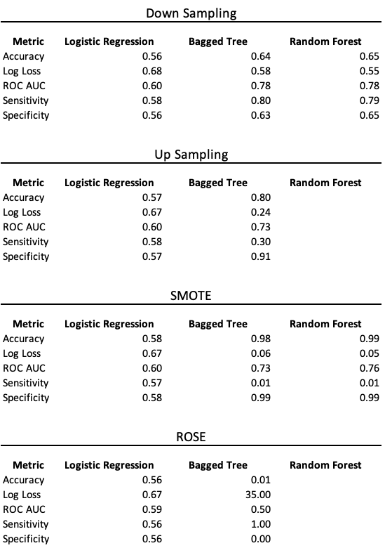

# 5. Resampling Part 2

## 5.1 Down Sampling

```r
# Creating our recipe
pitches_rec <- recipe(is_hr ~ ., data = pitches_train) %>%
    step_dummy(all_nominal(), -is_hr) %>%
    step_downsample(is_hr, under_ratio = 2.5)

# Add recipe to the workflow
pitches_wf <- workflow() %>%
    add_recipe(pitches_rec)
```

### a. Logistic Regression

```r
# Linear Model
doParallel::registerDoParallel()
glm_rs <- pitches_wf %>%
    add_model(glm_spec) %>%
    fit_resamples(resamples = pitches_folds, metrics = pitches_metrics,
        control = control_resamples(save_pred = TRUE))

collect_metrics(glm_rs)
```

| .metric | .estimator | mean | n | std_err | .config |
| --- | --- | --- | --- | --- | --- |
| accuracy | binary | 0.98008450 | 10 | 0.0007718946 | Preprocessor1_Model1 |
| mn_log_loss | binary | 0.33995320 | 10 | 0.0004523212 | Preprocessor1_Model1 |
| roc_auc | binary | 0.60499724 | 10 | 0.0053318588 | Preprocessor1_Model1 |
| sensitivity | binary | 0.01482454 | 10 | 0.0019446873 | Preprocessor1_Model1 |
| specificity | binary | 0.98867098 | 10 | 0.0007464201 | Preprocessor1_Model1 |

### b. Bagged Tree

```r
# Bagged Tree Model
doParallel::registerDoParallel()
bag_rs <- pitches_wf %>%
    add_model(bag_spec) %>%
    fit_resamples(resamples = pitches_folds, metrics = pitches_metrics,
        control = control_resamples(save_pred = TRUE))

collect_metrics(bag_rs)
```

| .metric | .estimator | mean | n | std_err | .config |
| --- | --- | --- | --- | --- | --- |
| accuracy | binary | 0.8529490 | 10 | 0.002799447 | Preprocessor1_Model1 |
| mn_log_loss | binary | 0.3103646 | 10 | 0.002173215 | Preprocessor1_Model1 |
| roc_auc | binary | 0.7768763 | 10 | 0.007277557 | Preprocessor1_Model1 |
| sensitivity | binary | 0.3879478 | 10 | 0.014868754 | Preprocessor1_Model1 |
| specificity | binary | 0.8570970 | 10 | 0.002755619 | Preprocessor1_Model1 |

### c. Random Forest

```r
# Random Forest Model
doParallel::registerDoParallel()
rf_rs <- pitches_wf %>%
    add_model(rf_spec) %>%
    fit_resamples(resamples = pitches_folds, metrics = pitches_metrics,
        control = control_resamples(save_pred = TRUE))

collect_metrics(rf_rs)
```

| .metric | .estimator | mean | n | std_err | .config |
| --- | --- | --- | --- | --- | --- |
| accuracy | binary | 0.9155876 | 10 | 0.002637451 | Preprocessor1_Model1 |
| mn_log_loss | binary | 0.3086905 | 10 | 0.001302602 | Preprocessor1_Model1 |
| roc_auc | binary | 0.7900383 | 10 | 0.005678065 | Preprocessor1_Model1 |
| sensitivity | binary | 0.2621241 | 10 | 0.013792879 | Preprocessor1_Model1 |
| specificity | binary | 0.9214116 | 10 | 0.002599417 | Preprocessor1_Model1 |

## 5.2 Other Techniques

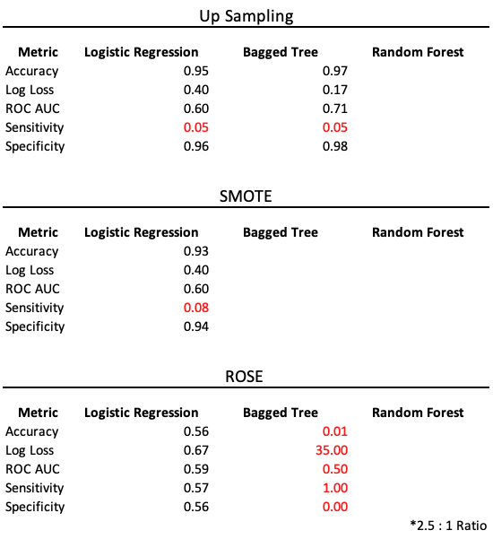

# 6. Evaluation

After running a series of models, a series of resampling techniques, and tuning the models by changing ratios, we can conclude that our best resampling technique will be down-sampling. To fine-tune this further, I continued to add non-home run data points by changing the ratio, and increased the ratio to include as many non-home-runs as possible without affecting the specificity and sensitivity.

This model is being evaluated on log loss score. Although the log loss scored actually increased from the initial model, I would argue this is a much useful model. A model that predicts no home run in every occurrence might be 99% accurate with a extremely low log-loss score but does not provide any use about our variables or what leads to home runs. There is a trade off in accuracy and having optimal sensitivity and specificity.

# 7. Final Model

```r
# Creating our recipe
pitches_rec <- recipe(is_hr ~ ., data = pitches_train) %>%
    step_dummy(all_nominal(), -is_hr) %>%
    step_downsample(is_hr, under_ratio = 2.5)

# Add recipe to the workflow
pitches_wf <- workflow() %>%
    add_recipe(pitches_rec)

# Bagged Tree Model
doParallel::registerDoParallel()
bag_rs_final <- pitches_wf %>%
    add_model(bag_spec) %>%
    fit_resamples(resamples = pitches_folds, metrics = pitches_metrics,
        control = control_resamples(save_pred = TRUE))

collect_metrics(bag_rs_final)
```

| .metric | .estimator | mean | n | std_err | .config |
| --- | --- | --- | --- | --- | --- |
| accuracy | binary | 0.8494475 | 10 | 0.003165250 | Preprocessor1_Model1 |
| mn_log_loss | binary | 0.3121313 | 10 | 0.001958083 | Preprocessor1_Model1 |
| roc_auc | binary | 0.7761119 | 10 | 0.006281164 | Preprocessor1_Model1 |
| sensitivity | binary | 0.3981099 | 10 | 0.006405222 | Preprocessor1_Model1 |
| specificity | binary | 0.8534647 | 10 | 0.003172104 | Preprocessor1_Model1 |

```r
final_wf <- workflow() %>%
    add_recipe(pitches_rec) %>%
    add_model(bag_spec)

final_modelfit <- fit(final_wf, train_df)

final_modelfit
## ══ Workflow [trained] ════════════════════════════════════════════════
## Preprocessor: Recipe
## Model: bag_tree()
##
## ── Preprocessor ──────────────────────────────────────────────────────
## 2 Recipe Steps
##
## • step_dummy()
## • step_downsample()
##
## ── Model ─────────────────────────────────────────────────────────────
## Bagged CART (classification with 25 members)
##
## Variable importance scores include:
##
## # A tibble: 38 × 4
##    term                value std.error  used
##    <chr>               <dbl>     <dbl> <int>
##  1 plate_height         596.      9.45    25
##  2 plate_side           591.      6.25    25
##  3 vert_release_angle   376.      6.85    25
##  4 vert_approach_angle  368.      6.06    25
##  5 release_speed        354.      6.95    25
##  6 induced_vert_break   332.      7.00    25
##  7 horz_release_angle   323.      6.73    25
##  8 spin_axis            317.      5.86    25
##  9 zone_speed           302.      6.18    25
## 10 rel_side             296.      5.63    25
## # … with 28 more rows
```

```r
preds <- predict(final_modelfit, pitches_test, type = "prob")

preds <- bind_cols(pitches_test, preds)
```

```r
preds <- predict(final_modelfit, new_data = test, type = "prob")
preds <- test %>%
    bind_cols(preds) %>%
    select(pitch_id, .pred_HR)
```